# Gustavo Diaz

## Combining List Experiments and the Network Scale Up Method

**Gustavo Díaz**  
McMaster University  
diazg2@mcmaster.ca

**Verónica Pérez Bentancur**  
Universidad de la República veronica.perez@cienciassociales.edu.uy

**Ines Fynn**  
Universidad Católica del Uruguay  
ines.fynn@ucu.edu.uy

**Lucía Tiscornia**  
University College Dublin  
lucia.tiscornia@ucd.ie

Slides: [gustavodiaz.org/talk](https://gustavodiaz.org/talk.html)

## Background

- Social scientists care about **sensitive issues**
- Asking about them directly leads to **misreporting**
- **Solution:** *Indirect questioning* techniques
- **List experiments** are a popular option

## Example

Now I am going to read you things that make people angry or upset

Adapted from [Kuklinski, Cobb, and Gilens (1997)](https://doi.org/10.1017/S0022381600053470)

## Example

After I read them all, tell me HOW MANY of them upset you

Adapted from [Kuklinski, Cobb, and Gilens (1997)](https://doi.org/10.1017/S0022381600053470)

## Example

I don’t want to know which ones, just tell me HOW MANY

### Control group

1. The federal government increasing tax on gasoline
2. Professional athletes getting million dollar contracts
3. Large corporations polluting the environment

Adapted from [Kuklinski, Cobb, and Gilens (1997)](https://doi.org/10.1017/S0022381600053470)

## Example

I don’t want to know which ones, just tell me HOW MANY

### Treatment group

1. The federal government increasing tax on gasoline
2. Professional athletes getting million dollar contracts
3. Large corporations polluting the environment

Adapted from [Kuklinski, Cobb, and Gilens (1997)](https://doi.org/10.1017/S0022381600053470)

## Example

I don’t want to know which ones, just tell me HOW MANY

### Treatment group

1. The federal government increasing tax on gasoline
2. Professional athletes getting million dollar contracts
3. Large corporations polluting the environment
4. **A black family moving next door**

Adapted from [Kuklinski, Cobb, and Gilens (1997)](https://doi.org/10.1017/S0022381600053470)

## Problem: Low statistical precision

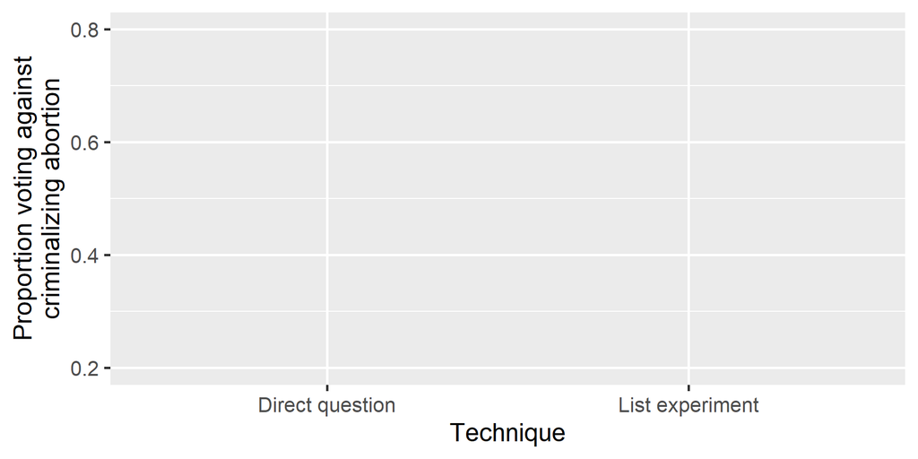

Adapted from [Rosenfeld, Imai, and Shapiro (2016)](https://doi.org/10.1111/ajps.12205)

## Problem: Low statistical precision

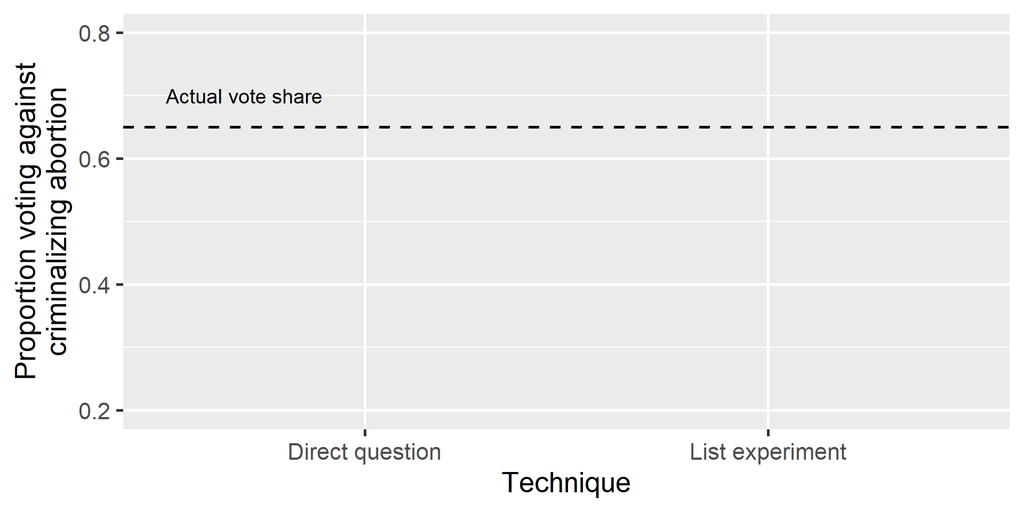

Adapted from [Rosenfeld, Imai, and Shapiro (2016)](https://doi.org/10.1111/ajps.12205)

## Problem: Low statistical precision

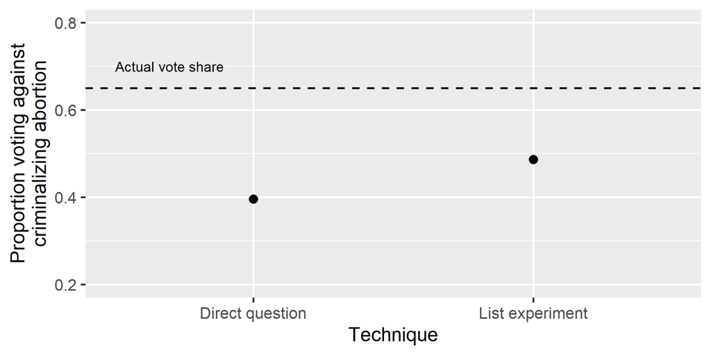

Adapted from [Rosenfeld, Imai, and Shapiro (2016)](https://doi.org/10.1111/ajps.12205)

## Problem: Low statistical precision

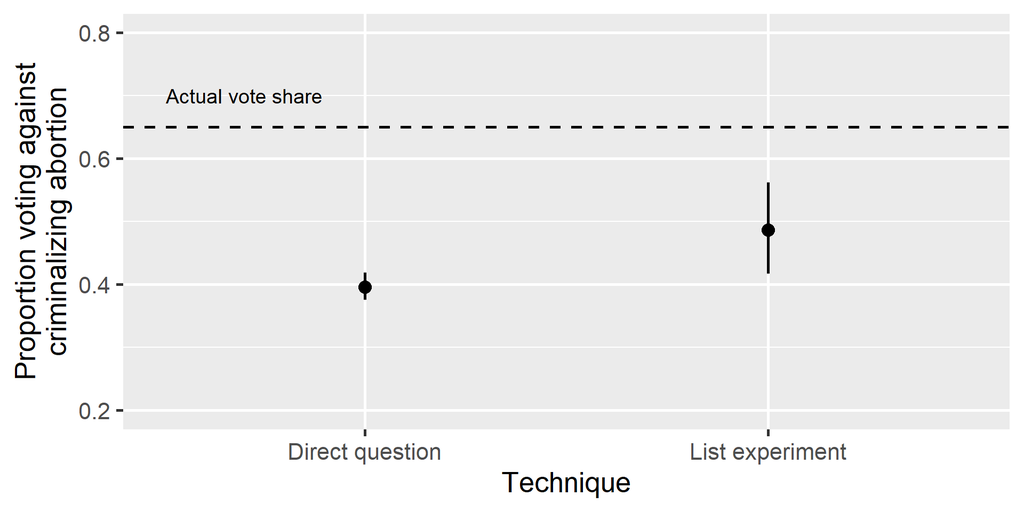

Adapted from [Rosenfeld, Imai, and Shapiro (2016)](https://doi.org/10.1111/ajps.12205)

## Ways to improve precision

- Negatively correlated items [(Glynn 2013)](https://doi.org/10.1093/poq/nfs070)
- Covariate adjustment [(Blair and Imai 2012)](https://doi.org/10.1093/pan/mpr048)
- Auxiliary information [(Chou 2020)](https://doi.org/10.1177/0049124117729711)
- Double list experiments [(Diaz 2023)](https://gustavodiaz.org/files/research/dle_test.pdf)
- Combine with direct questions [(Aronow et al 2015)](https://doi.org/10.1093/jssam/smu023)

## Ways to improve precision

- Negatively correlated items [(Glynn 2013)](https://doi.org/10.1093/poq/nfs070)
- Covariate adjustment [(Blair and Imai 2012)](https://doi.org/10.1093/pan/mpr048)
- Auxiliary information [(Chou 2020)](https://doi.org/10.1177/0049124117729711)
- Double list experiments [(Diaz 2023)](https://gustavodiaz.org/files/research/dle_test.pdf)
- **Combine with direct questions [(Aronow et al 2015)](https://doi.org/10.1093/jssam/smu023)**

## Combined estimator

- **Logic:** You don’t need a list experiment for those who admit to the sensitive item in the direct question

$$\hat{\mu} = \overline{X} + (1 - \overline{X}) (\overline{V}_{1,0} - \overline{V}_{0,0})$$

**Source:** [Aronow et al (2015)](https://doi.org/10.1093/jssam/smu023)

## Combined estimator

- **Logic:** You don’t need a list experiment for those who admit to the sensitive item in the direct question

$$\hat{\mu} = \underbrace{\overline{X}}_\text{Prop direct question yes} + \underbrace{(1 - \overline{X})}_\text{Weight} \times \underbrace{(\overline{V}_{1,0} - \overline{V}_{0,0})}_\text{LE diff-in-means if direct question no}$$

**Source:** [Aronow et al (2015)](https://doi.org/10.1093/jssam/smu023)

## Combined estimator

- **Logic:** You don’t need a list experiment for those who admit to the sensitive item in the direct question

$$\hat{\mu} = \underbrace{\underbrace{\overline{X}}_\text{Prop direct question yes} + \underbrace{(1 - \overline{X})}_\text{Weight} \times \underbrace{(\overline{V}_{1,0} - \overline{V}_{0,0})}_\text{LE diff-in-means if direct question no}}_\text{Weighted average of prevalence rates}$$

**Source:** [Aronow et al (2015)](https://doi.org/10.1093/jssam/smu023)

## Problem

- Can’t always include direct questions
- Need an indirect questioning technique that lets us **infer individual responses to sensitive item**
- But most rely on anonymity
- Can’t combine without extra assumptions, altered designs, or population-level data

## Network Scale-Up Method (NSUM)

How many people do you know,

Adapted from [McCarty et al (2001)](https://doi.org/10.17730/humo.60.1.efx5t9gjtgmga73y). Original has 29 anchors and 3 target groups

## Network Scale-Up Method (NSUM)

How many people do you know, **who also know you,**

Adapted from [McCarty et al (2001)](https://doi.org/10.17730/humo.60.1.efx5t9gjtgmga73y). Original has 29 anchors and 3 target groups

## Network Scale-Up Method (NSUM)

How many people do you know, **who also know you, with whom you have interacted in the last year**

Adapted from [McCarty et al (2001)](https://doi.org/10.17730/humo.60.1.efx5t9gjtgmga73y). Original has 29 anchors and 3 target groups

## Network Scale-Up Method (NSUM)

How many people do you know, **who also know you, with whom you have interacted in the last year** in person, by phone, or any other channel.

- Named Michael
- Named Christina
- Gave birth in the past 12 months
- Commercial pilots
- **Have tested positive for HIV**

Adapted from [McCarty et al (2001)](https://doi.org/10.17730/humo.60.1.efx5t9gjtgmga73y). Original has 29 anchors and 3 target groups

## Why NSUM?

- Can infer **individual** responses to sensitive item

**Assumption**

If someone knows a unusually large number of people with the sensitive item, then they are likely to hold the sensitive item too.

- If true, can use NSUM responses instead of direct questions
- **Goal:** Find individuals with large *sensitive network* relative to *personal network*

## Hierarchical model

$$\begin{align*}
y_{ik} \sim \text{negative-binomial}( & \text{mean} = e^{\alpha_i + \beta_k},\\ & \text{overdispersion} = \omega_k)
\end{align*}$$

- $y_{ik}$: Degree of group $k$ for person $i$
- $\alpha_i$: Expected degree of person $i$ (logged)
- $\beta_k$: Expected degrees of group $k$ (logged)
- $\omega_k$: Controls variance in propensity to know someone from group $k$

**Details:** [Zheng, Salganik, and Gelman (2006)](https://doi.org/10.1198/016214505000001168); [Calvo and Murillo (2013)](https://doi.org/10.1177/0010414012463882)

## Hierarchical model

- Fit with MLE in two steps `(Personal network, sensitive group network)`
- Focus on standardized residuals:

$$r_{ik} = \sqrt{y_{ik}} - \sqrt{e \alpha_i + \beta_k}$$

- **High residual:** Higher exposure to sensitive item

**Details:** [Ventura, Ley, and Cantú (2023)](https://doi.org/10.1177/00104140231169035)